# Projet final : Classification bayésienne et Analyse Factorielle Discriminante

Paul Cascarino et Mathis Quinio-Cosquer

Février 2023

# Classification bayésienne et Analyse Factorielle Discriminante

## 1. Préambule

### Contexte

De nos jours, il y a une forte montée des IA capable de comprendre ainsi que de créer du langage humain. Ces IA sont appelés **Large Language Models (LLM)** et sont très récemment démocratisé par l’apparition brusque de Chat gpt et de nombreux autres.

Ces IA sont capable de générer du texte, il est difficile pour un humain de savoir si le texte est fait par une IA ou non.

Dans ce projet, nous nous intéresseront à savoir si une machine serait capable de détecter cela.

### Les objectifs de ce projet

Les objectifs de ce proet sont donc de développer un système de classification qui utilise des **méthodes bayésienne** ainsi que des caractéristiques extraintes par l’**analyse factorielle discriminante (AFD)**

Dans le but de faire la distinction entre le texte généré par l’IA et par l’Homme

## 2. Données et prétraitements

### Description du jeu de données

#### Préparation et imports

Dans un premier temps, nous effaçons la mémoire :

```r
rm(list=ls())
```

Et faisons les chargements des packages nécessaires :

```r
library(ggplot2)
library(dplyr)
library(stringr)

# Permet la tokenization : https://smltar.com/tokenization#types-of-tokens
library(tokenizers)
# Permet l'utilisation de liste pour le stop-words : https://smltar.com/stopwords#premadestopwords
library(stopwords)
# Permet la stemmatization : https://smltar.com/stemming#how-to-stem-text-in-r
library(SnowballC)

# Permet le calcul du score de lisibilité
library(quanteda.textstats)
# Permet la séparation en donnés d'entrainements et de test
library(caret)
library(tm)
library(text2vec)
library(slam)

library(MASS)
library(e1071)
```

#### Chargement des données

Les données sont récupérés sur le site kaggle à l’adresse : https://www.kaggle.com/competitions/llm-detect-ai-generated-text Nous pouvons ainsi récupérer le csv récupéré avec :

```r
path_essays <- 'datasets/llm-detect-ai-generated-text/train_essays.csv'
path_prompts <- 'datasets/llm-detect-ai-generated-text/train_prompts.csv'

df_essays <- read.csv(path_essays)
df_prompts <- read.csv(path_prompts)
```

Nous verrons par la suite que le df ne sera paas suffisant, ainsi nous commençons intégrons dès à présent de nouvelles variables :

```r
df_comp <- read.csv('datasets/train_drcat_03.csv')
head(df_comp$fold)
```

```
## [1] 1 2 8 8 8 5
```

```r
colnames(df_comp) <- c('id', 'text', 'generated', 'del', 'del2', 'prompt_id' )
colnames(df_essays)
```

```
## [1] "id"        "prompt_id" "text"      "generated"
```

```r
df_comp <- subset(df_comp, select=c('id', 'text', 'generated', 'prompt_id'))
df_comp <- df_comp[, colnames(df_essays)]

dim(df_essays)
```

```
## [1] 1378    4
```

```r
dim(df_comp)
```

```
## [1] 42206     4
```

```r
df_essays <- rbind(df_essays, df_comp)

# Afficher les nouvelles colonnes de df_essays
dim(df_essays)
```

```
## [1] 43584     4
```

#### Description d essays :

Voici un aperçu de nos données :

Nous avons un dataframe **d’essays** qui sont soit écrits par des humains soit générés par des LLM :

```r
df_essays[1,]
```

```
##         id prompt_id
## 1 0059830c         0
##                                                                                                                                                                                                                                                                                                          …
## 1 Cars. Cars have been around since they became famous in the 1900s, when Henry Ford created and built the first ModelT. Cars have played a major role in our every day lives since then. But now, people are starting to question if limiting car usage would be a good thing. To me, limiting the use o…
##   generated
## 1         0
```

Regradons ses colonnes :

```r
colnames(df_essays)
```

```
## [1] "id"        "prompt_id" "text"      "generated"
```

Nous avons :

- “id” : qui est l’unique ID pour chaque essay
- “prompt_id” : permet d’identifier le prompt de l’essay
- “text” : le texte de l’essay
- “generated” : 0 si généré par Homme 1 si non, est une variable catégorielle =>

```r
df_essays$generated <- as.factor(df_essays$generated)
```

Dans l’exemple ci dessus (la première ligne), nous avons un texte écris en anglais par un homme (generated = 0)

```r
dim(df_essays)
```

```
## [1] 43584     4
```

Nous avons une liste de 43584 essays et donc de 4 colonnes cités ci-dessus

```r
summary(df_essays)
```

```
##       id              prompt_id         text           generated
##  Length:43584       Min.   :0.000   Length:43584       0:31167
##  Class :character   1st Qu.:2.000   Class :character   1:12417
##  Mode  :character   Median :4.000   Mode  :character
##                     Mean   :4.373
##                     3rd Qu.:7.000
##                     Max.   :9.000
```

Nous supprimons les éléments dupliqués :

```r
sum(duplicated(df_essays))
```

```
## [1] 139
```

```r
df_essays <- unique(df_essays)
sum(duplicated(df_essays))
```

```
## [1] 0
```

Nous remarquons aussi qu’il n’y a pas d’éléments nuls

```r
sum(is.na(df_essays))
```

```
## [1] 0
```

Regarsons maintenant notre colonne text :

```r
df_essays$text[500]
```

```
## [1] "State senator I ask that you favor the idea of keeping the Electoral College instead of changing it to election by popular vote for the president of the United States.\n\nEven though the Electoral College is a despised method for choosing the president it has it's reasons. I'll show you why …
```

Nous avons de long textes écrits en anglais avec des sauts de ligne () et de la ponctuation.

Regardons la répartition de la longueur des textes :

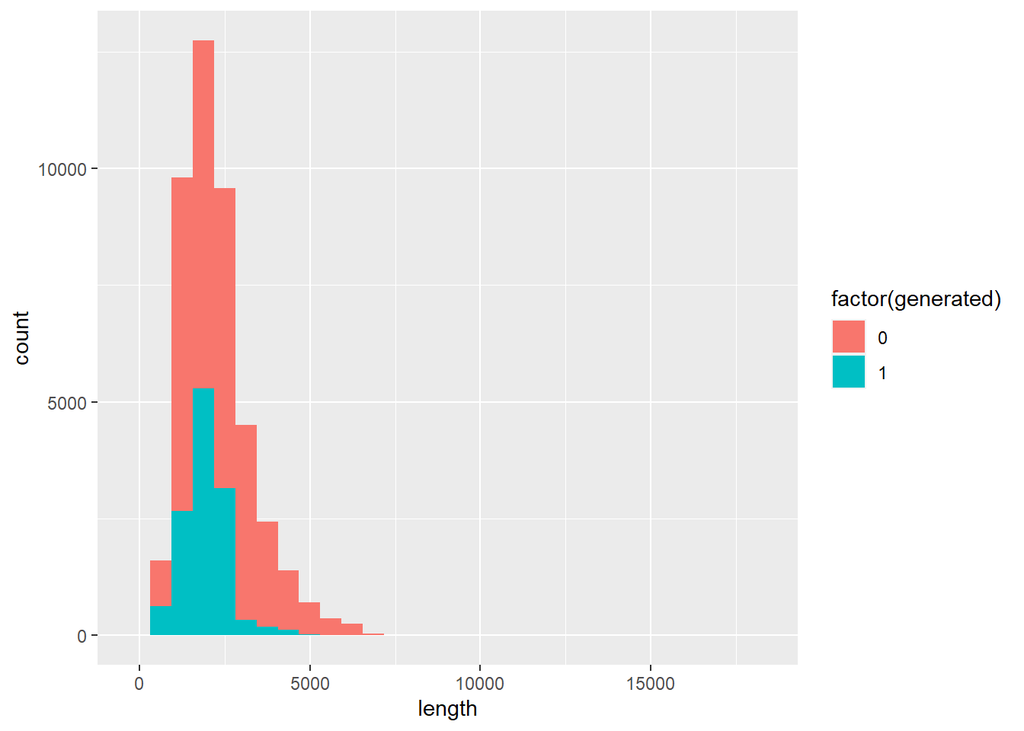

```r
nchar_df <- data.frame(length = nchar(df_essays$text))
nchar_df$generated <- df_essays$generated

plot <- ggplot(nchar_df, aes(x = length, fill = factor(generated))) + geom_histogram()

plot
```

Nous remarquons que nous avons des textes de longueurs très variables. La distribution des longueurs des textes semble ne pas donner beaucoup d’information autre que nes ne disposons probablement pas de textes de longueur abbérantes

Regardons la répartition des textes écrits pas les humains ou IA :

```r
df_essays$generated <- factor(df_essays$generated)
levels(df_essays$generated)
```

```
## [1] "0" "1"
```

nous avons donc bien 2 levels 0 pour Homme et 1 pour IA

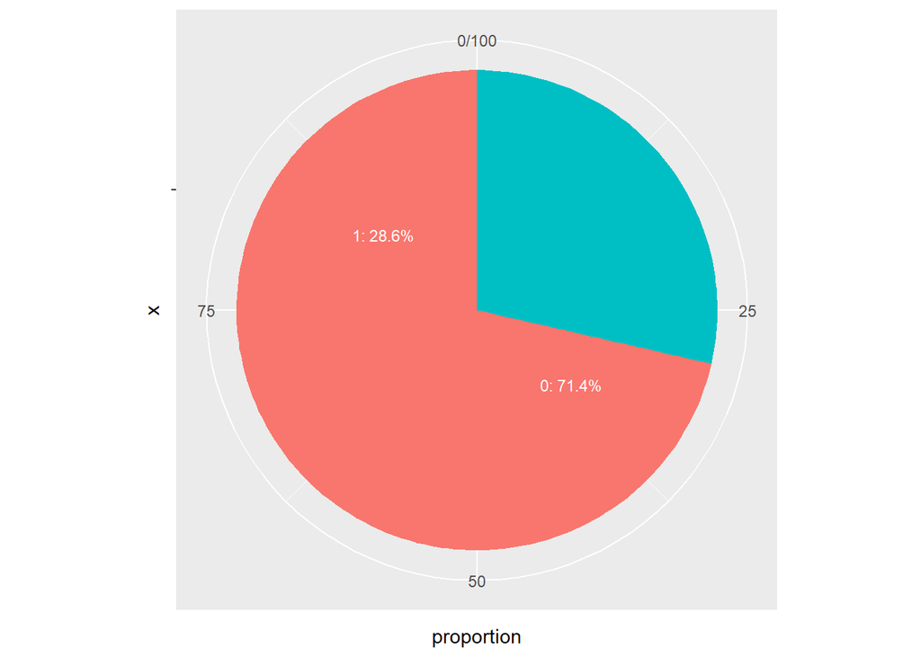

```r
pie_chart <- function(generated_col) {
  generated <- data.frame(
    generated = generated_col
  )

  generated <- generated %>%
                  count(generated) %>%
                  mutate(proportion = n / sum(n) * 100) %>%
                  mutate(ypos = cumsum(proportion) - 0.5 * proportion)

  pie_chart <- ggplot(generated, aes(x = '', y = proportion, fill = generated)) +
                geom_bar(stat = 'identity', width = 1) +
                coord_polar('y', start = 0) +
                theme(legend.position = 'none') +
                geom_text(aes(x = '', y = ypos, label = paste0(generated, ": ", round(proportion, 1), "%")), color = 'white', size = 3)

  return(pie_chart)
}

# Exécuter la fonction avec la colonne generated
pie_chart(df_essays$generated)
```

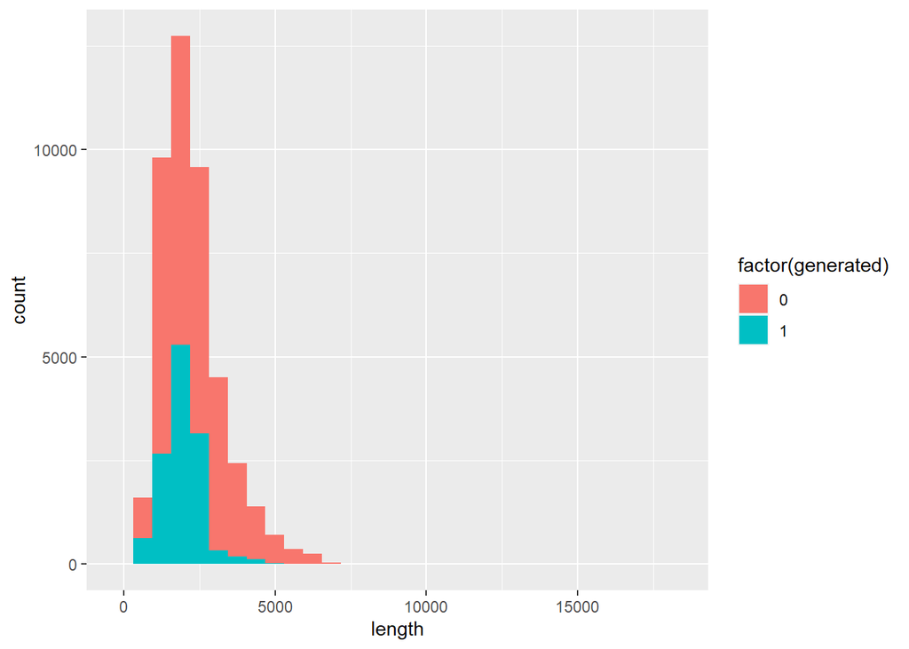

```r
nchar_df <- data.frame(length = nchar(df_essays$text))
nchar_df$generated <- df_essays$generated

plot <- ggplot(nchar_df, aes(x = length, fill = factor(generated))) + geom_histogram()

plot
```

Cependant nous nous rendons bien compte que les textes écrits par des humains sont bien plus long que ceux écrits par des IA. La longueur du texte est peut être une feature à prendre en compte.

```r
df_generated_1 <- subset(df_essays, generated == 1)
dim(df_generated_1)
```

```
## [1] 12416     4
```

Notre dataframe de promt nous permets de voir les promts données aux Hommes ou LLM qui on donnés lieux aux essay.

Les 2 sont liés par le “prompt_id”.

```r
colnames(df_prompts)
```

```
## [1] "prompt_id"    "prompt_name"  "instructions" "source_text"
```

Nous avons :

- “prompt_id” : qui est unique pour chaque prompt
- “prompt_name” : Le titre du prompt
- “instructions” : Les instructions données aux étudiants (Humains)
- “source_text” : La source (articles) des essays pour répondre aux prompts

```r
dim(df_prompts)
```

```
## [1] 2 4
```

Après avoir passé **BEAUCOUP** de temps à essayer de faire fonctionner notre df_prompts correctement, nous nous apercevons qu’il y a beaucoup de valeurs manquantes et nous pensons qu’il n’est pas nécessaire aux méthodes que nous allons utiliser

Ainsi nous avons pour plus de simplicité

```r
df <- df_essays
```

### Etapes de prétraitements

#### Nettoyage des données textuelles

Nous avons 1 colonne avec des données textuelles non catégorielle : **text**

Pour nétoyer nous allons créer une fonction qui vas : - mettre tous les textes en minuscule - supprimer les chiffres - supprimer tous les caractères spéciaux - retirer les sauts de lignes

```r
clean_text <- function(df_col){
  temp_col <- str_to_lower(df_col)
  temp_col <- str_replace_all(temp_col, "'", " ")
  temp_col <- str_replace_all(temp_col, "[0-9]", "")
  temp_col <- str_replace_all(temp_col, "[^[:alnum:][:space:]]", "")
  temp_col <- str_replace_all(temp_col, "\n", "")

  return(temp_col)
}

df$tidy <- clean_text(df$text)

head(df$tidy)
```

```
## [1] "cars cars have been around since they became famous in the s when henry ford created and built the first modelt cars have played a major role in our every day lives since then but now people are starting to question if limiting car usage would be a good thing to me limiting the use of cars m…
## [2] "transportation is a large necessity in most countries worldwide with no doubt cars buses and other means of transportation make going from place to place easier and faster however there s always a negative pollution although mobile transportation are a huge part of daily lives we are endange…
## [3] "america s love affair with it s vehicles seems to be cooling says elisabeth rosenthal to understand rosenthal s perspective it is easier to suggest that america s car usage is decreasing slowly this isn t necessarily bad in the sense that it has certain positive effects the advantages of lim…
## [4] "how often do you ride in a car do you drive a one or any other motor vehicle to work the store to the mall have you ever thought about how many people in the world do that exact same thing travel to every destination using a fuel powered motorvehicle not many people realize the intensive dam…
## [5] "cars are a wonderful thing they are perhaps one of the worlds greatest advancements and technologies cars get us from point a to point i that is exactly what we want isnt it we as humans want to get from one place to anther as fast as possiile cars are a suitaile to do that they get us acros…
## [6] "the electrol college system is an unfair system people don t have the right to select their own president they dont have the right to select a president because when people vote they are technically voting for the electors for a candied that candidate can be a democratic or a republican in s…
```

La fonction **clean_text** nous permet de supprimer les caractères non alphanumériques et les chiffres ainsi que de touus mettre en minuscule.

Nous pouvons maintenant apppliquer la Tokenization :

#### Tokenization

https://smltar.com/tokenization

Nous décidons dans un premier temps de faire une tokenization par mots car c est la méthode la plus commune et que cela nous parait logique de travailler dans un premier temps avec les mots.

De plus nous avons vu grâce au mini projet 1 que c’est la plus performante par rapports à la tokenization par pluusieurs mots en terme d’accuracy :

```r
df$token <- tokenize_words(df$tidy)

df$token[1]
```

```
## [[1]]
##   [1] "cars"         "cars"         "have"         "been"         "around"
##   [6] "since"        "they"         "became"       "famous"       "in"
##  [11] "the"          "s"            "when"         "henry"        "ford"
##  [16] "created"      "and"          "built"        "the"          "first"
##  [21] "modelt"       "cars"         "have"         "played"       "a"
##  [26] "major"        "role"         "in"           "our"          "every"
##  [31] "day"          "lives"        "since"        "then"         "but"
##  [36] "now"          "people"       "are"          "starting"     "to"
##  [41] "question"     "if"           "limiting"     "car"          "usage"
##  [46] "would"        "be"           "a"            "good"         "thing"
##  [51] "to"           "me"           "limiting"     "the"          "use"
##  [56] "of"           "cars"         "might"        "be"           "a"
##  [61] "good"         "thing"        "to"           "doin"         "like"
##  [66] "matter"       "of"           "this"         "article"      "in"
```

[output cut: 102 more lines]

Nous pouvons maintenant observer les tokens les plus utilisés :

Utilisons la fonction du mini-projet 1 :

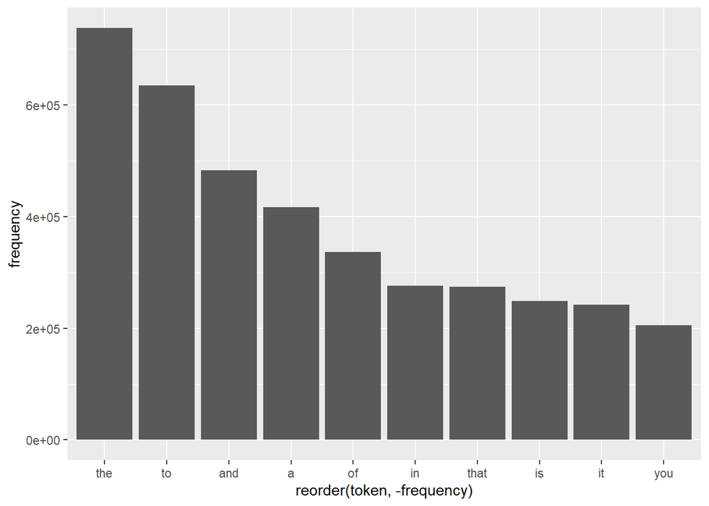

```r
give_most_words <- function(df_tokens, col_names, n){
  token_freq <- table(unlist(df_tokens[[col_names]]))
  token_freq_df <- data.frame(token = names(token_freq), frequency = as.numeric(token_freq))
  token_freq_df <- token_freq_df[order(-token_freq_df$frequency),]
  plot <- ggplot(token_freq_df[0:n,], aes(x=reorder(token, -frequency), y=frequency)) +
            geom_bar(stat = 'identity')
  return(list(plot=plot, df=token_freq_df))
}
result <- give_most_words(df[, c('token', 'generated')], 'token', 10)

result$plot
```

**Explication :**

Nous avons définit une fonction qui permet de retourner un graph des n premiers mots et longeurs fréquences d apparition dans notre df.

Nous remarquons que nous avons une liste de mots inutiles. Regardons maintenant les stop words :

##### Stop words

Les **stop words** sont les mots qui n ont pas d intérêts dans le sens de la phrase. Ansi les supprimer réduirait le nombre de feature et donc le nombre de calculs. Nous pouvons aussi penser que réduire les mots inutiles réduirait la performance de notre futur modèle.

Pour cela nous allons utiliser une liste de stop words déjà faite, Nous allons donc utiliser la bibliothèque **snowball**.

```r
head(stopwords::stopwords(source = "snowball"))
```

```
## [1] "i"      "me"     "my"     "myself" "we"     "our"
```

```r
cat("Nombre de mots des textes avant l'étape des stop words : ",
sum(lengths(df$token)))
```

```
## Nombre de mots des textes avant l'étape des stop words :  17073896
```

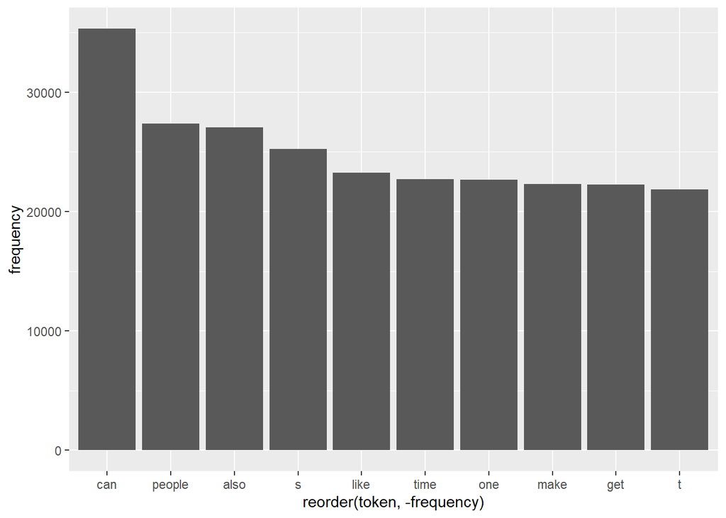

```r
df$stopwords <- sapply(df$token, function(x) setdiff(x, stopwords::stopwords(source = "snowball")))

result <- give_most_words(df[, c('stopwords', 'generated')], 'stopwords', 10)

result$plot
```

```r
cat("Nombre de mots des textes après l'étape des stop words : ",
sum(lengths(df$stopwords)))
```

```
## Nombre de mots des textes après l'étape des stop words :  5206201
```

##### Stemming

Le stemming permet de rapprocher les mots similaires tel que ‘feel’ et ‘feels’ en un stem qui est un mot de base (ex:‘feel’).

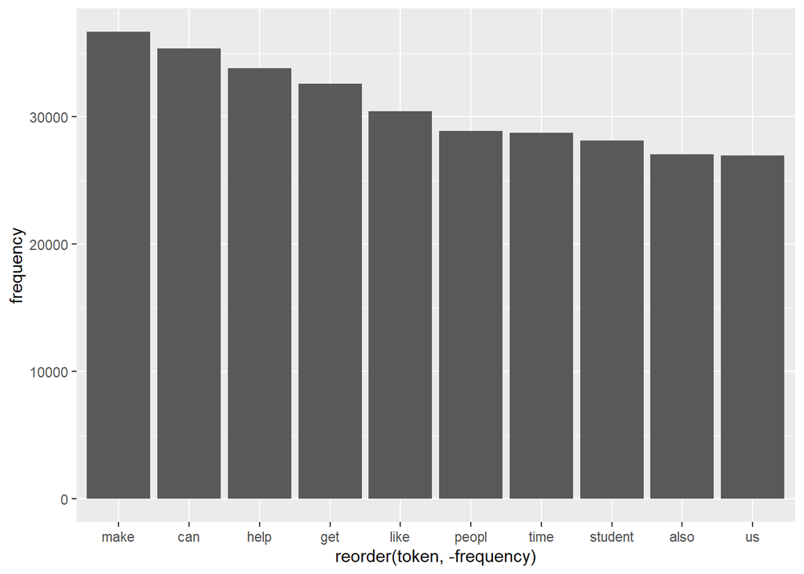

```r
df$stem <- lapply(df$stopwords, function(x) wordStem(x))

result <- give_most_words(df[, c('stem', 'generated')], 'stem', 10)

result$plot
```

Nous remarquons bien la différence après l étape du stemming et l appartition de nouveaux mots.

## 3. Extraction de caractéristiques (Feature Extraction)

#### Réduction des données

Pour réduire le runtime

```r
nbr_row_little_df <- 10000

df <- df[sample(nrow(df), nbr_row_little_df),]

dim(df)
```

```
## [1] 10000     8
```

### Caractéristiques linguistiques et stylométriques

Regardons certaines caractéristiques qui pourraient différencier les écrits humains aux IA :

#### Calcul du nombre de phrase

Pour cela nous splitons toous nos textes en phrase avec :

```r
df$phrases <- lapply(strsplit(df$text, "[.!?]\\s|\n"), unlist)

# Suppression des éléments vides
df$phrases <- lapply(df$phrases, function(x) Filter(nzchar, x))

head(df$phrases[1])
```

```
## [[1]]
## [1] "the author supports his ideas very well because, he tells why its important to study venus and why it is the worthy pursuit despite the dangers"
## [2] "The author also says ¨venuse is the closest planet to earth in terms of density and size¨.They have aslo sent numerous spacecrafts and have done previouse missions"
## [3] "The pervious missions was unmanned"
## [4] "There has not been a spaceship that has touched venuse and why, the author said that gthe reason that spaceship or has not landed was becuse it would not last mor than just a few hours"
## [5] "The author supports the idea that studying venus is worthy pursuit despit the dangers, because know that i read the story icould see why"
## [6] "Venus might be dangers to go to and explore but by making spacecrafts and more andmakeing experiment it probably would not be so dangerous to send spacecraft or maybe a spaceshit to try it out again."
```

Ainsi il est simple d’avoir le nombre de phrase par essay avec

```r
df$p_nbr <- sapply(df$phrases, length)
head(df$p_nbr)
```

```
## [1]  6 17 17 13 36 38
```

```r
cat('Nombre moyennes des phrases dans les essays : ',mean(df$p_nbr))
```

```
## Nombre moyennes des phrases dans les essays :  20.5165
```

#### Calcul de la moyenne des longueurs des phrases

```r
df$p_moy_chars <- sapply(df$phrases, function(phrases) mean(nchar(phrases)))
head(df$p_moy_chars)
```

```
## [1] 143.1667 121.1765 116.4706 146.8462 108.5000 107.5526
```

```r
cat('Nombre moyennes des caractères par phrases ', mean(df$p_moy_chars))
```

```
## Nombre moyennes des caractères par phrases  118.2764
```

#### Calcul des scores de lisibilités

Nous pouvons aussi calculer le score de lisibilité avec la package **quanteda.textstats**. Cela peut peut être nous donner une information quant à la différences des écrits humain et des IA

```r
df$read_score <- textstat_readability(df$text)$Flesch
head(df$read_score)
```

```
## [1] 57.97828 51.62305 25.69894 43.93295 63.67875 33.99242
```

```r
cat('Nombre moyennes des scores de lisibilité ', mean(df$read_score))
```

```
## Nombre moyennes des scores de lisibilité  55.87593
```

#### Regard sur les caractères non alphanumérique

Nous voullons aussi regarder si la ponctuation et le nombre de caractères utilisés nous donnerai des information quant à la différences des écrits humain et des IA.

Nous pouvons ainsi compter le nombre de caractères émis : Nous utiliserons la librairie **stringr** pour plus de simplicité

```r
df$ponct_count <- str_count(df$text, "[[:punct:]]")
head(df$ponct_count)
```

```
## [1]  10  24  35  55  90 105
```

```r
cat('Nombre moyennes des ponctuations écrites ', mean(df$ponct_count))
```

```
## Nombre moyennes des ponctuations écrites  46.9449
```

Nous pouvons aussi faire un ration ponctuation / nombre de caractère

```r
df$ponct_ratio <- df$ponct_count / nchar(df$text)
head(df$ponct_ratio)
```

```
## [1] 0.01150748 0.01139601 0.01736111 0.02839442 0.02261307 0.02522826
```

```r
cat('Nombre moyennes des ponctuations / caractères ', mean(df$ponct_ratio))
```

```
## Nombre moyennes des ponctuations / caractères  0.02088547
```

### Technique de vectorisation utilisée

#### Explication

- Cela permet de réduire la dimensionnalité de notre texte
- Identifier les termes important et ainsi pouvoir reconnaitre les redondances des IA par exemples
- Réduire le bruits, les mots peu utilisés et non utiles

On a :
$$\text{IDF}(t, D) = \log\left(\frac{N}{\text{df}(t)}\right)$$
avec

- N : le nombre documents total
- df(t) : le nombre de documents comportant le terme t

Ainsi IDF(t,D) donne le poids IDF du terme t dans les documents de D. Cela correspond à l importance du mot dans notre corpus de documents.

#### Suréchantillonnage

Nous n avons pas beaucoup de données écrites par les IA, nous pouvons dupliquer leurs lignes afin d’apporter un plus gros poids à celles ci.

```r
dim(df)
```

```
## [1] 10000    14
```

```r
set.seed(1)

df_H <- df[df$generated == 0, ]
df_IA <- df[df$generated == 1, ]

# Calcul du facteur de duplication
n <- nrow(df_H) / nrow(df_IA)


df_IA_plus <- df_IA[rep(1:nrow(df_IA), times = ceiling(n)), ]

df_plus <- rbind(df_H, df_IA_plus)
dim(df_plus)
```

```
## [1] 15974    14
```

Avec l’import de nouvelles données l étaape du suréchaantillonnage ne vas pas être prise en compte.

#### Séparation en données d’entrainements et de test

```r
set.seed(1)


pourcentage <- 0.7

indices <- createDataPartition(df$generated, p = pourcentage, list = FALSE)

# df_train <- df_plus[indices, ]
# df_test <- df_plus[-indices, ]

df_train <- df[indices, ]
df_test <- df[-indices, ]


# Afficher la taille des ensembles d'entraînement et de test
cat("Taille de l'ensemble d'entraînement :", nrow(df_train), "\n")
```

```
## Taille de l'ensemble d'entraînement : 7001
```

```r
cat("Taille de l'ensemble de test :", nrow(df_test), "\n")
```

```
## Taille de l'ensemble de test : 2999
```

```r
give_tfidf <- function(df_train, df_test, term_count_min){

    # Créer un itoken
  itoken_train <- itoken(df_train$stem)
  itoken_test <- itoken(df_test$stem)

  # Créer le vocabulaire
  vocabulary <- create_vocabulary(itoken_train)
  vocabulary <- prune_vocabulary(vocabulary, term_count_min)

  vectorizer <- vocab_vectorizer(vocabulary)

  dtm_train <- create_dtm(itoken_train, vectorizer)
  dtm_test <- create_dtm(itoken_test, vectorizer)

  train_matrix <- as.matrix(as(dtm_train, "CsparseMatrix"))
  test_matrix <- as.matrix(as(dtm_test, "CsparseMatrix"))

  return(list(train = train_matrix, test = test_matrix))
}
tfidfs <- give_tfidf(df_train, df_test, 50)

df_train$tfidf <- tfidfs$train
df_test$tfidf <- tfidfs$test
```

## 4. Analyse des facteurs discriminants

### Explication de l AFD

#### Résumé de nos colonnes

```r
colnames(df_train)
```

```
##  [1] "id"          "prompt_id"   "text"        "generated"   "tidy"
##  [6] "token"       "stopwords"   "stem"        "phrases"     "p_nbr"
## [11] "p_moy_chars" "read_score"  "ponct_count" "ponct_ratio" "tfidf"
```

Seulement de nombreuses sont la modifications d’autres réduisons cela popur éviter la redondances

```r
df_train_afd <- subset(df_train, select = c("generated", "p_nbr", "p_moy_chars", "read_score", "ponct_count", "ponct_ratio" ))
df_test_afd <- subset(df_test, select = c("generated", "p_nbr", "p_moy_chars", "read_score", "ponct_count", "ponct_ratio" ))
# Créer le sous-ensemble de colonnes sans la colonne tfidf et afficher le résumé statistique
summary(df_train_afd[, c("generated", "p_nbr", "p_moy_chars", "read_score", "ponct_count", "ponct_ratio")])
```

```
##  generated     p_nbr        p_moy_chars        read_score       ponct_count
##  0:4910    Min.   : 1.00   Min.   :  10.64   Min.   :-695.61   Min.   :  1.00
##  1:2091    1st Qu.:14.00   1st Qu.:  89.36   1st Qu.:  48.73   1st Qu.: 29.00
##            Median :20.00   Median : 109.13   Median :  59.39   Median : 42.00
##            Mean   :20.51   Mean   : 118.99   Mean   :  55.60   Mean   : 47.08
##            3rd Qu.:26.00   3rd Qu.: 130.73   3rd Qu.:  69.34   3rd Qu.: 59.00
##            Max.   :90.00   Max.   :3122.00   Max.   : 100.82   Max.   :263.00
##   ponct_ratio
##  Min.   :0.0006013
##  1st Qu.:0.0161290
##  Median :0.0196418
##  Mean   :0.0209593
##  3rd Qu.:0.0241122
##  Max.   :0.1408657
```

```r
df_train_afd <- as.data.frame(df_train$tfidf)
df_train_afd$generated <- df_train$generated

df_test_afd <- as.data.frame(df_test$tfidf)
df_test_afd$generated <- df_test$generated

dim(df_train_afd)
```

```
## [1] 7001 1953
```

```r
dim(df_test_afd)
```

```
## [1] 2999 1953
```

```r
# Ajuster le modèle LDA sans spécifier le nombre de composantes
model_lda <- lda(generated ~ ., data = df_train_afd)

# Obtenir le nombre de composantes générées par le modèle
num_components <- ncol(predict(model_lda)$x)

# Utiliser les résultats du modèle LDA pour sélectionner toutes les composantes discriminantes
selected_lda_components <- predict(model_lda)$x[, 1:num_components]


# Ajouter la variable cible au nouveau jeu de données
df_selected_components <- data.frame(selected_lda_components, generated = df_train_afd$generated)

# Résumé des composantes discriminantes sélectionnées
head(df_selected_components)
```

```
##   selected_lda_components generated
## 1               -1.071108         0
## 2                5.315967         1
## 3               -2.740447         0
## 4                5.128817         1
## 5               -2.453797         0
## 6                4.166880         1
```

```r
predicted_lda_test <- predict(model_lda, newdata = df_test_afd)

predicted_lda_components_test <- predicted_lda_test$x[, 1:num_components]

df_test_components <- data.frame(predicted_lda_components_test, generated = df_test_afd$generated)
```

## 5. Classification bayésienne

```r
df_selected_components$p_nbr <- df_train$p_nbr
df_selected_components$p_moy_chars <- df_train$p_moy_chars
df_selected_components$read_score <- df_train$read_score
df_selected_components$ponct_count <- df_train$ponct_count
df_selected_components$ponct_ratio <- df_train$ponct_rati

df_test_components$p_nbr <- df_test$p_nbr
df_test_components$p_moy_chars <- df_test$p_moy_chars
df_test_components$read_score <- df_test$read_score
df_test_components$ponct_count <- df_test$ponct_count
df_test_components$ponct_ratio <- df_test$ponct_ratio




model_bayes <- naiveBayes(generated ~ ., data = df_selected_components)
summary(model_bayes)
```

```
##           Length Class  Mode
## apriori   2      table  numeric
## tables    6      -none- list
## levels    2      -none- character
## isnumeric 6      -none- logical
## call      4      -none- call
```

```r
predictions <- predict(model_bayes, newdata = df_test_afd)
accuracy <- sum(predictions == df_test_afd$generated) / length(df_test_afd$generated)
accuracy
```

```
## [1] 0.7012337
```

## 6. Conclusion

### Améliorations possibles

Nous n’avons pas eu le temps de faire la validation croisé de manière convenable ainsi que la présentation des résultats. Nous nous sommes donc concentrés sur le travail en fouille et permettre d’obtenir le meilleur preprocessing car les aspects manquants sont dévelopés dans d’autres matières. (en python).